# Reproducible Research Report

Rustam Mansyrov

Sunday, September 20, 2015

# Introduction

To begin with, the project is elaborated on data describing personal movement using activity monitoring devices such as a Fitbit, Nike Fuelband, or Jawbone Up. The data consists of 5 minute intervals during the day, steps taken in each interval and date which interval belongs to. The data was collected by anonimous and the period of collecting it is two months, namely, October and November, 2012.

As requested, there are very interesting questions posed to be answered in this report.

- What is mean total number of steps taken per day?
- What is the average daily activity pattern?
- Imputing missing values, and re-answering the first question.
- Are there differences in activity patterns between weekdays and weekends?

The analysis is made using R-statistical software and the respective codes are provided below so that the whole analysis is entirely reproducible.

# Analysis

Before starting working on the data, the necessary preprocessing along with R codes are summarized below.

```r
library(lubridate)
library(dplyr)
library(ggplot2)
dir.create("project_rr")
setwd("./project_rr")
fileUrl <- "http://d396qusza40orc.cloudfront.net/repdata%2Fdata%2Factivity.zip"
download.file(fileUrl, destfile = "data.zip")
unzip("data.zip", exdir = ".")
data <- read.csv("activity.csv", header = TRUE, colClasses = c("numeric", "character", "integer"))
file.remove("data.zip")
data$date <- ymd(data$date)
```

Uploading of required packages, creating and setting the appropriate directory, downloading and uploading of the data are made above. Besides, the date format is changed in order to facilitate the way to deal with dates in our project.

To answer the first question, the important point to state is that the data contains some missing values and they are ignored at this step of analysis. The data is grouped with respect to days and summarized in a way it shows the total number of steps taken each day.

```r
sum_data <- group_by(data, date) %>%
        summarize(Total_Number = sum(steps)) %>%
        as.data.frame()
```

Then, the code below makes the histogram of total number of steps taken each day:

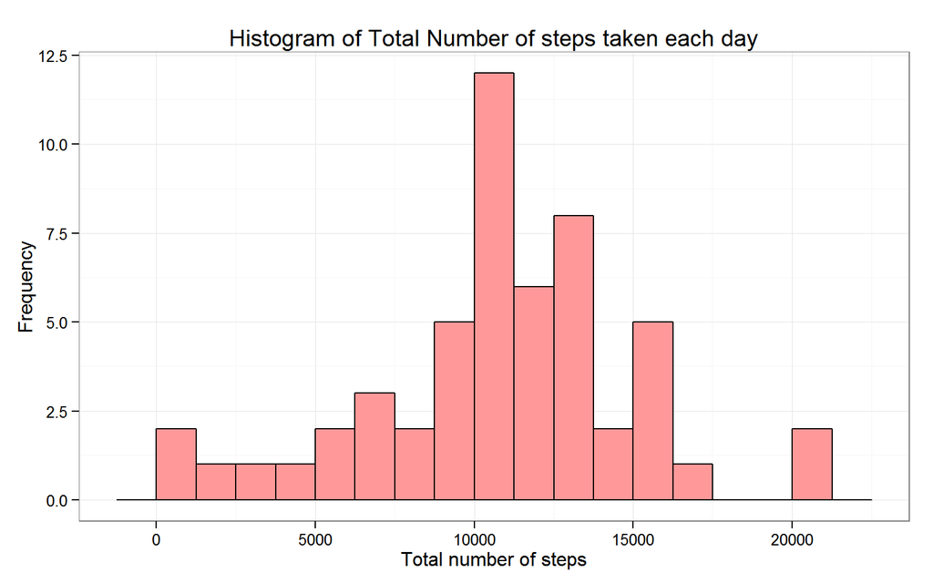

```r
g1 <- ggplot(sum_data, aes(x = Total_Number))
g1 <- g1 + geom_histogram(color = "black", fill = "#FF9999", binwidth = 1250)
g1 <- g1 + labs(title = "Histogram of Total Number of steps taken each day")
g1 <- g1 + theme(text = element_text(size = 15, face = "italic"), axis.title = element_text(size = 12))
g1 <- g1 + labs(x = "Total number of steps", y = "Frequency")
g1 <- g1 + theme_bw()
g1
```

Then, the codes provided below report mean and median for total number of steps taken each day.

```r
mean(select(sum_data, Total_Number)[,1], na.rm = T)
```

```
## [1] 10766.19
```

```r
median(select(sum_data, Total_Number)[,1], na.rm = T)
```

```
## [1] 10765
```

Answering the second question, the daily activity pattern is concerned. In other words, we want to observe what happens to the steps taken every 5 minute interval. To prepare the data, the important step is to group it by interval and summarize with repspect to average of steps taken in a respective interval.

```r
interval_data <- group_by(data, interval) %>%
        summarize(mean = mean(steps, na.rm = TRUE)) %>%
        as.data.frame()
```

The best way to observe the pattern is to plot the time-series plot, which is done with the help of below codes.

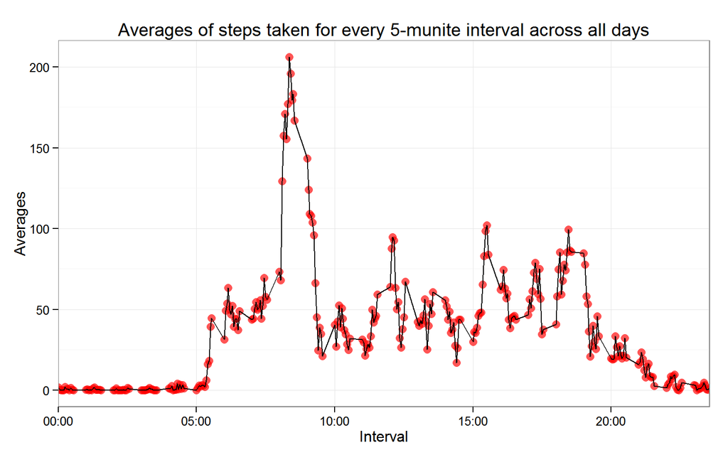

```r
g2 <- ggplot(interval_data, aes(x = interval, y = mean, group = 1))
g2 <- g2 + geom_point(size = 3, alpha = 2/3, color = "red") + geom_line(color = "black")
g2 <- g2 + scale_x_discrete(breaks = c(0, 500, 1000, 1500, 2000),
                            labels = c("00:00", "05:00", "10:00", "15:00", "20:00"))
g2 <- g2 + labs(x = "Interval", y = "Averages")
g2 <- g2 + ggtitle("Averages of steps taken for every 5-munite interval across all days")
g2 <- g2 + theme(text = element_text(size = 15, face = "italic"), axis.title = element_text(size = 12))
g2 <- g2 + theme_bw()
g2
```

From the plot above, we can see that the biggest average of steps taken accross all days is in the 07:00 - 09:00 o`clock interval. To be precise, the following shows the exact interval which has the maximum average of steps taken across all days.

```r
max_steps_inteval <- interval_data[which(max(select(interval_data, mean)) == select(interval_data, mean)),1]
max_steps_inteval
```

```
## [1] 835
```

So, 835th interval has the maximum average of steps taken. In other words, 8:35 - 8:40 time interval has the maximum average of steps taken across all days. We can assume, that this interval indicates the time when everyone goes to school, university or work and having the maximum average steps is quite reasonable.